# Effects of Customers on Bike Rental Patterns

## Data Exploration - Ford GoBike System Data Analysis

### *Jhonatan Nagasako*

#### *28-FEB-2021*

# Introduction

This notebook will focus on the **data EXPLORATION** of Ford GoBike System. Data source can be found via [Udacity provided link to Google Docs/Drive](https://docs.google.com/document/d/e/2PACX-1vQmkX4iOT6Rcrin42vslquX2_wQCjIa_hbwD0xmxrERPSOJYDtpNc_3wwK_p9_KpOsfA6QVyEHdxxq7/pub?embedded=True).

This data set includes information about individual rides made in a bike-sharing system covering the greater San Francisco Bay area.

- Note that this dataset will require some data wrangling in order to make it tidy for analysis. There are multiple cities covered by the linked system, and multiple data files will need to be joined together if a full year’s coverage is desired.

Questions to consider:

1. As a customer, when is it a good time to schedule a bike ride to avoid the rush (high influx of customers)?
2. As a shop owner, how should you strategically schedule your employees to ensure enough staff is present to assist customers?
3. As a shop owner, how can I exploit customer renting patterns to adjust prices of rides (e.g., bike-use-time/hr) or create discounts?

*The analysis endeavored below will address these questions, specifically in the conclusion section of this report*

## Investigation Overview

In this investigation in to the Ford GoBike system (i.e., bike renting service), I'm most interested in figuring out critical times and dates which high frequency of customers is expected. Thus, allowing strategies to be developed to create targeted marketing and lean staffing schedules.

The following features that will have the strongest effect in developing these strategies is by analyzing

1. Age
2. Gender
3. Ride duration
4. Days bikes rented
5. Times bikes rented

*New features were created for time and date as required. The final cleaned and tidied data was exported as a `master.csv` file, then read back into the report as a `df`.*

## Dataset Overview

There are 183,215 ride entries in the dataset with 27 features (see above for details). Most variables are categorical in nature (specifically a data type of string). Data extraction of date, date day, and time (hr, min, etc.) was broken apart from the `start_time` and `end_time`.

Also, the following assumptions were made for the data. First, the data only considers a two month span, Feb and Mar. secondly, the ride's start-days vs end-days were practically the same day. Lastly, the analysis of different locations which rides occurred is out of scope of this data project.

## Preliminary Wrangling

### **Please note to reader, details of any cleaning or tidying of the dataset can be seen in Section 2 - Assessing Data (Cleaning and Tidying) of the Notebook Report (not shown in this slide show)**

```
----Shape of File (row, column)---

(183215, 27)

----Data Names---
```

|  | start_month | end_month | start_day_of_week | end_day_of_week | start_day | end_day | start_hour | end_hour | start_time | end_time | ... | end_station_id | end_station_name | end_station_latitude | end_station_longitude | bike_id | user_type | member_birth_year | age | member_gender | bike_share_for_all_trip |
| --- | --- | --- | --- | --- | --- | --- | --- | --- | --- | --- | --- | --- | --- | --- | --- | --- | --- | --- | --- | --- | --- |
| 0 | FEB | MAR | THU | FRI | 2019-02-28 | 2019-03-01 | 17:32:10.145000 | 08:01:55.975000 | 2019-02-28 17:32:10.145 | 2019-03-01 08:01:55.975 | ... | 13.0 | Commercial St at Montgomery St | 37.794231 | -122.402923 | 4902 | Customer | 1984 | 35 | Male | No |
| 1 | FEB | MAR | THU | FRI | 2019-02-28 | 2019-03-01 | 18:53:21.789000 | 06:42:03.056000 | 2019-02-28 18:53:21.789 | 2019-03-01 06:42:03.056 | ... | 81.0 | Berry St at 4th St | 37.775880 | -122.393170 | 2535 | Customer | 0 | 0 | 0 | No |
| 2 | FEB | MAR | THU | FRI | 2019-02-28 | 2019-03-01 | 12:13:13.218000 | 05:24:08.146000 | 2019-02-28 12:13:13.218 | 2019-03-01 05:24:08.146 | ... | 3.0 | Powell St BART Station (Market St at 4th St) | 37.786375 | -122.404904 | 5905 | Customer | 1972 | 47 | Male | No |
| 3 | FEB | MAR | THU | FRI | 2019-02-28 | 2019-03-01 | 17:54:26.010000 | 04:02:36.842000 | 2019-02-28 17:54:26.010 | 2019-03-01 04:02:36.842 | ... | 70.0 | Central Ave at Fell St | 37.773311 | -122.444293 | 6638 | Subscriber | 1989 | 30 | Other | No |
| 4 | FEB | MAR | THU | FRI | 2019-02-28 | 2019-03-01 | 23:54:18.549000 | 00:20:44.074000 | 2019-02-28 23:54:18.549 | 2019-03-01 00:20:44.074 | ... | 222.0 | 10th Ave at E 15th St | 37.792714 | -122.248780 | 4898 | Subscriber | 1974 | 45 | Male | Yes |

5 rows × 27 columns

```
----Basic Statitics of Dataframe---
```

|  | duration_hr | duration_min | duration_sec | start_station_id | start_station_latitude | start_station_longitude | end_station_id | end_station_latitude | end_station_longitude | bike_id | member_birth_year | age |
| --- | --- | --- | --- | --- | --- | --- | --- | --- | --- | --- | --- | --- |
| count | 183215.000000 | 183215.000000 | 183215.000000 | 183215.000000 | 183215.000000 | 183215.000000 | 183215.000000 | 183215.000000 | 183215.000000 | 183215.000000 | 183215.000000 | 183215.000000 |
| mean | 0.201639 | 12.098367 | 725.902017 | 138.590427 | 37.771615 | -122.353104 | 136.249123 | 37.771820 | -122.352689 | 4473.218792 | 1895.288475 | 32.607909 |
| std | 0.498633 | 29.917978 | 1795.078654 | 111.778864 | 0.098914 | 0.116387 | 111.515131 | 0.098819 | 0.115961 | 1665.249372 | 412.013105 | 12.067822 |
| min | 0.016944 | 1.016667 | 61.000000 | 3.000000 | 37.317298 | -122.453704 | 3.000000 | 37.317298 | -122.453704 | 11.000000 | 0.000000 | 0.000000 |
| 25% | 0.090278 | 5.416667 | 325.000000 | 47.000000 | 37.770407 | -122.412408 | 44.000000 | 37.770407 | -122.411726 | 3777.000000 | 1979.000000 | 26.000000 |
| 50% | 0.142778 | 8.566667 | 514.000000 | 104.000000 | 37.780760 | -122.398285 | 100.000000 | 37.781010 | -122.398279 | 4958.000000 | 1987.000000 | 31.000000 |
| 75% | 0.221111 | 13.266667 | 796.000000 | 239.000000 | 37.797280 | -122.287180 | 235.000000 | 37.797320 | -122.288665 | 5503.000000 | 1992.000000 | 38.000000 |
| max | 23.734444 | 1424.066667 | 85444.000000 | 398.000000 | 37.880222 | -121.874119 | 398.000000 | 37.880222 | -121.874119 | 6645.000000 | 2001.000000 | 99.000000 |

## Univariate Exploration

## Figure 0 - Age Distribution of Riders

1. The data was trimmed to 100 years old based on [research of oldest living person](https://www.google.com/search?q=oldest+person+alive&rlz=1C1GCEB_enUS893US893&oq=oldest+person&aqs=chrome.0.0i433j69i57j0l2j0i67j0l5.3255j0j7&sourceid=chrome&ie=UTF-8). As expected, that data is right skewed. Interestingly enough, the 95 percentiles was 55 years old, despite the maximum being 100 years old. The 5th percentile rider age was 22 years old. The mean age of riders (regardless of gender) was about 34.2 years old.
2. No transformations additional transformations was required for the data analysis.
3. There was ages with "0 years old" and also astronomically old ages calculated.
4. Data was filtered to remove ages less than 1 years hold and trimmed to 100 year old (based on research of the [2010 U.S. Census Bureu](https://www.census.gov/prod/cen2010/briefs/c2010br-03.pdf)). Ages with 0 years old calculated is unlikely to have the ability to ride a bike... This was supported by the fact that the 5th percentile rider's age was 22 years old. Additionally, for the scope of this report 100 years old was chosen based on the fact that the 95th percentile rider's age was 55 years old.

```
The mean = 34.2 Years Old
The 5th Percentile =  22.0 Years old
The 95th Percentile =  55.0 Years old
```

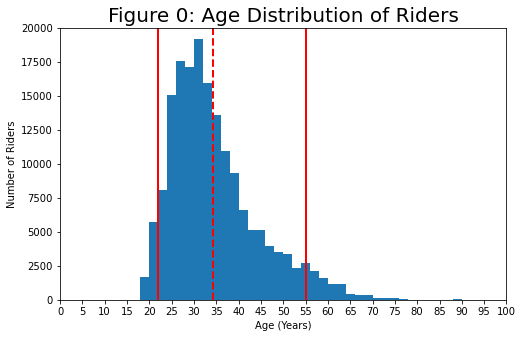

## Figure 1 - Top Days to START a Bike Ride

1. The day of the week was reviewed to determine what day had the highest in flux of customers. Most notably Tuesday through Thursday were the most popular days to rent bikes--Thursday being the most with 35176 customers overall. Conversely, Saturday through Monday were the least--Saturday being the least with 15,377 customers.
2. No transformations additional transformations was required for the data analysis.
3. It was unusual to see the weekend (Sat and Sun) as the lowest count of customers. As compared to Thursday, which is in the middle of the work week--perhaps the job title of customer should be collected to understand if customers are "working professionals" vs "students".
4. No additional cleaning was required for the dataset after initial cleaning, details shown in **Section 2 - Assessing Data (Cleaning and Tidying)**

```
Most popular to least popular days to rent bike
 start_day_of_week
THU    35176
TUE    31781
WED    29609
FRI    28962
MON    26807
SUN    15503
SAT    15377
Name: start_day_of_week, dtype: int64
```

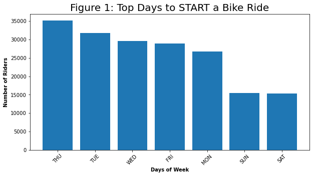

## Figure 2 - Top Times to START a Bike Ride

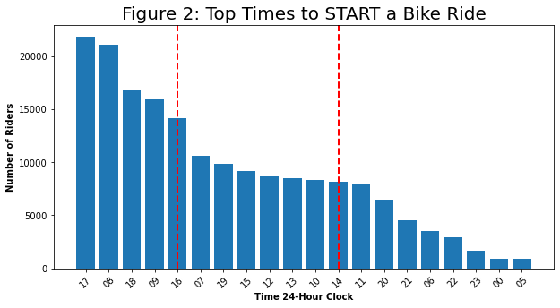

## Figure 3 - Top Times to END a Bike Ride

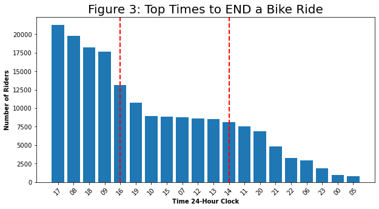